JuliaActuary

Practical, extensible, and open-source actuarial modeling and analysis.

# Poisson approximation to Binomial

This notebook explores using the Poissson approximation to the Binomial. This can be useful for a number of reasons:

1. The Binomial probability mass formula becomes more unwieldy for large $N$ faster than it does for the Poisson.
2. In actuarial, and other contexts, $N$ can be a non-integer value (think partial period exposures) and rounding up or down could materially distort the posterior estimate if $N$ is small.

We will look at the approximation across a range of parameters $q$ (the probabilty a binomial event occurs) and $N$ (the number of chances for the event to occur, or "exposures").

Under certain conditions, the Poisson distribution can approximate the Binomial, where the average number of events, $λ=N*q$.

What are those conditions? [According to Wikipedia](https://en.wikipedia.org/wiki/Binomial_distribution#Poisson_approximation):

> According to two rules of thumb, this approximation is good if n ≥ 20 and p ≤ 0.05, or if n ≥ 100 and np ≤ 10.

It's not really that simple, and arguably a bit restrictive as this notebook will show.

## Approach

We will use Julia and Turing.jl to simulate the posterior distribution. Our prior for the parameter $q$ will be ${Uniform} = Beta(1,1)$.

We will sample from the posterior using the No-U-Turn (NUTS) sampler, and aggregate the results of the chains over 30 trials of simulated outcomes for the given $q$ and $N$.

This is overkill for a toy problem where we could just model the parameters themselves, but it demonstrates using Bayesian MCMC techniques in a simple, exploratory fashion.

We begin by importing the relevant packages:

```julia
begin
    using Turing
    using CairoMakie
    using StatsBase
    using MCMCChains
    using DataFrames
    using ThreadsX
    using Logging
    using Markdown
end
```

## Define the Models

```julia
@model function poisson(N,n_events)
    q ~ Beta(1,1)

    n_events ~ Poisson(q*N)
end
```

```
poisson (generic function with 2 methods)
```

```julia
@model function binom(N,n_events)
    q ~ Beta(1,1)

    n_events ~ Binomial(N,q)
end
```

```
binom (generic function with 2 methods)
```

## Simulation Parameters

```julia
trials = 30
```

```
30
```

```julia
qs = [0.05,0.25,0.5,0.75,0.95]
```

```
5-element Vector{Float64}:
 0.05
 0.25
 0.5
 0.75
 0.95
```

```julia
Ns = [10,25,50,100,250,500,1000,5000]
```

```
8-element Vector{Int64}:
   10
   25
   50
  100
  250
  500
 1000
 5000
```

```julia
model_points =  [(;q,N) for q in qs, N in Ns]
```

```
5×8 Matrix{NamedTuple{(:q, :N), Tuple{Float64, Int64}}}:
 (q = 0.05, N = 10)  (q = 0.05, N = 25)  (q = 0.05, N = 50)  …  (q = 0.05, N = 5000)
 (q = 0.25, N = 10)  (q = 0.25, N = 25)  (q = 0.25, N = 50)     (q = 0.25, N = 5000)
 (q = 0.5, N = 10)   (q = 0.5, N = 25)   (q = 0.5, N = 50)      (q = 0.5, N = 5000)
 (q = 0.75, N = 10)  (q = 0.75, N = 25)  (q = 0.75, N = 50)     (q = 0.75, N = 5000)
 (q = 0.95, N = 10)  (q = 0.95, N = 25)  (q = 0.95, N = 50)     (q = 0.95, N = 5000)
```

## Sample from the Posterior

```julia
Logging.disable_logging(Logging.Warn); #Disable warning logs to improve sampling time
```

This is a collection of samples (chains) from Markov chains that are sampled in proportion to the posterior density. If this is new to you, I highly recommend the book *Statistical Rethinking*:

```julia
@time bpchains = map(model_points) do mp

    ThreadsX.map(1:trials) do i
        claims = sum(rand() < mp.q for _ in 1:mp.N)
        bc = sample(binom(mp.N,claims), NUTS(), 500)
        pc = sample(poisson(mp.N,claims), NUTS(), 500)

        (;bc,pc)
    end
end
```

[output not shown]

[output not shown]

## Results

The fit remains poor when $q >> 0.5$ and when $N$ is small.

### Visualization

This visualization shows the aggregated posterior distribution across all of the trials and model points. The darker shaded band indicates the middle 50% of the posterior:

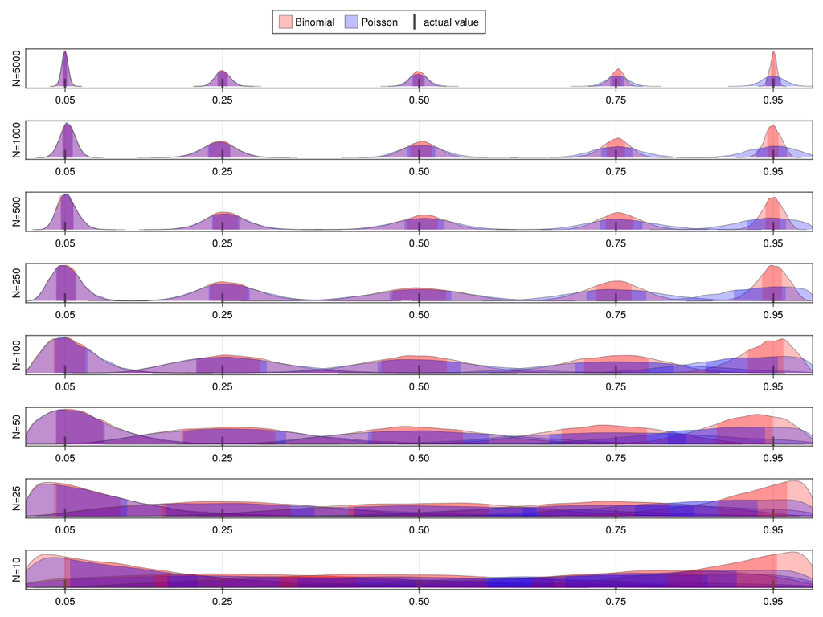

```julia
let
    f = Figure(resolution=(1280,960))
    a = Any # outer variable to set as axis for to grab legend

    for (i,N) in enumerate(reverse(Ns))
        ax = Axis(f[i+1,1:10],
        xticks=qs,
        ylabel="N=$N"
        )
        a = ax
        xlims!(0,1)
        model_idx = findall(x->x.N == N,model_points)

        for n in model_idx
            c = bpchains[n]
            q = model_points[n].q
            y = model_points[n].N
            bpoints = vcat([x.bc["q"][:] for x in c]...)
            ppoints = vcat([x.pc["q"][:] for x in c]...)
            @show bpoints
            bqtls = quantile(bpoints,[.25,.75])
            pqtls = quantile(ppoints,[.25,.75])
            j = density!(
                bpoints,
                linewidth=10,
                strokewidth = 1,
                strokecolor = (:grey30,0.6),
                label="Binomial",
            	color=(:red,.25),
            )
            plot_band_under!(ax,j,0,bqtls[1],bqtls[2],"Binomial")


            j = density!(
                ppoints,
                color=(:blue,.25),
                linewidth=10,
                strokewidth = 1,
                strokecolor = (:grey30,0.6),
                label="Poisson",
            )
            plot_band_under!(ax,j,0,pqtls[1],pqtls[2],"Poisson")

            hideydecorations!(ax,label=false)
        end

        scatter!(
            qs,
            zeros(length(qs)),
            marker = :vline,
            markersize=20,
            color=:grey30,
            label="actual value"
            )
    end

    Legend(f[1,5],a,unique=true,orientation=:horizontal)
    f
end
```

```julia
function plot_band_under!(ax,plot,y,low,high,label="")
    function points(plot)
        pts = plot.plots[2].converted[1][]
        [p[1] for p in pts], [p[2] for p in pts]
    end
    xs′, ys′ = points(plot)

    filt = findall(x-> (x ≥ low) && (x ≤ high),xs′)
    b = band!(ax,xs′[filt], fill(y,length(filt)), ys′[filt], color=(plot.color, 0.9),transparency=true,shading = false,) # 0.25 alpha
    translate!(b,0,0,5)
end
```

```
plot_band_under! (generic function with 2 methods)
```

Built with Julia 1.8.3 and

CairoMakie 0.8.13  
DataFrames 1.3.4  
MCMCChains 5.3.1  
StatsBase 0.33.21  
ThreadsX 0.1.10  
Turing 0.21.12

## Run this Pluto Notebook

*To run this page locally, download this file and open it with [Pluto.jl](https://plutojl.org).*

The packages in JuliaActuary are open-source and liberally licensed (MIT License) to allow wide private and commercial usage of the packages, like the base Julia language and many other packages in the ecosystem. See terms of this site.

© JuliaActuary Contributors. Last modified: November 23, 2022. Website built with Franklin.jl and [Julia](https://julialang.org).